# Machine Learning

Niko Karajannis

Tuesday, June 16, 2015

## Introduction

Data from accelerometers on the belt, forearm, arm, and dumbell of 6 participants are used to perform predictive analysis on a test set of 20 observations.

## Preliminaries

First, the training dataset is read in. NAs have been defined in the same step. These columns are removed in the next step. Then the data is cleaned from the first 7 columns that contain information which would cause problems in the analysis. Finally, all variables set to numeric.

```r
data <- read.csv("pml-training.csv", na.strings=c("#DIV/0!", "", "NA"))
data <- data[,colSums(is.na(data))<19000]  ##get rid of columns with many NA
data <- data[,-(1:7)]  ##get rid of variables name, timestamp etc.
data[,1:52] <- sapply(data[,1:52], as.numeric)   ##make all variables numeric
```

Then, a seed is set and the dataset is partitioned into a training set and a validation set.

```r
set.seed(1)
library(caret)
inTrain <- createDataPartition(y=data$classe, p=0.7, list=FALSE)
training <- data[inTrain,]
validation <- data[-inTrain,]
```

Before starting the analysis, some preprocessing is done. None of the variables seems to have near zero inflation.

```r
nearZeroVar(training, saveMetrics=TRUE)
```

```
##                      freqRatio percentUnique zeroVar   nzv
## roll_belt             1.084142   10.69694373   FALSE FALSE
## pitch_belt            1.136364   19.98000571   FALSE FALSE
## yaw_belt              1.135593   20.19423022   FALSE FALSE
## total_accel_belt      1.047106    0.39988575   FALSE FALSE
## gyros_belt_x          1.015968    1.58526135   FALSE FALSE
## gyros_belt_y          1.130929    0.84261640   FALSE FALSE
## gyros_belt_z          1.077922    2.18508997   FALSE FALSE
## accel_belt_x          1.032028    2.17080834   FALSE FALSE
## accel_belt_y          1.146947    1.81376750   FALSE FALSE
## accel_belt_z          1.070552    3.78463296   FALSE FALSE
## magnet_belt_x         1.038462    3.75606969   FALSE FALSE
## magnet_belt_y         1.052402    3.57040845   FALSE FALSE
## magnet_belt_z         1.017647    5.41273922   FALSE FALSE
## roll_arm             46.615385   27.29220223   FALSE FALSE
## pitch_arm            75.750000   30.24850043   FALSE FALSE
## yaw_arm              28.186047   30.21993716   FALSE FALSE
## total_accel_arm       1.009375    0.91402456   FALSE FALSE
## gyros_arm_x           1.051429    8.55469866   FALSE FALSE
## gyros_arm_y           1.626437    4.98429020   FALSE FALSE
## gyros_arm_z           1.034653    3.01342474   FALSE FALSE
## accel_arm_x           1.032258   10.26849472   FALSE FALSE
## accel_arm_y           1.025316    7.22650671   FALSE FALSE
## accel_arm_z           1.148936   10.09711511   FALSE FALSE
## magnet_arm_x          1.031250   17.88060554   FALSE FALSE
## magnet_arm_y          1.181818   11.75378463   FALSE FALSE
## magnet_arm_z          1.282051   16.88089117   FALSE FALSE
## roll_dumbbell         1.037736   89.86003999   FALSE FALSE
## pitch_dumbbell        1.981818   88.17480720   FALSE FALSE
## yaw_dumbbell          1.145833   89.38874607   FALSE FALSE
## total_accel_dumbbell  1.078629    0.58554699   FALSE FALSE
## gyros_dumbbell_x      1.177340    3.04198800   FALSE FALSE
## gyros_dumbbell_y      1.228571    3.49900029   FALSE FALSE
## gyros_dumbbell_z      1.046948    2.38503285   FALSE FALSE
## accel_dumbbell_x      1.072000    5.19851471   FALSE FALSE
## accel_dumbbell_y      1.011236    6.05541274   FALSE FALSE
## accel_dumbbell_z      1.055556    5.41273922   FALSE FALSE
## magnet_dumbbell_x     1.147059   13.08197658   FALSE FALSE
## magnet_dumbbell_y     1.064935   11.12539274   FALSE FALSE
## magnet_dumbbell_z     1.028571    8.74035990   FALSE FALSE
## roll_forearm         13.333333   19.30876892   FALSE FALSE
## pitch_forearm        54.400000   28.44901457   FALSE FALSE
## yaw_forearm          14.156250   19.16595258   FALSE FALSE
## total_accel_forearm   1.155963    0.91402456   FALSE FALSE
## gyros_forearm_x       1.005376    3.62753499   FALSE FALSE
## gyros_forearm_y       1.045113    9.68294773   FALSE FALSE
## gyros_forearm_z       1.022472    3.74178806   FALSE FALSE
## accel_forearm_x       1.314286   10.76835190   FALSE FALSE
## accel_forearm_y       1.105263   13.18194801   FALSE FALSE
## accel_forearm_z       1.050000    7.28363325   FALSE FALSE
## magnet_forearm_x      1.062500   18.56612396   FALSE FALSE
## magnet_forearm_y      1.363636   23.46472436   FALSE FALSE
## magnet_forearm_z      1.000000   20.62267923   FALSE FALSE
## classe                1.485566    0.07140817   FALSE FALSE
```

However, some of the variables show multicollinearity (cor > .9). These variables are removed from both the training and the validation set.

```r
ncol(training)
```

```
## [1] 53
```

```r
descrCorr <- cor(training[,1:52])
highCorr <- findCorrelation(descrCorr, 0.90)
training <- training[, -highCorr]
validation <- validation[, -highCorr]
ncol(training)
```

```
## [1] 46
```

```r
ncol(validation)
```

```
## [1] 46
```

Now the random forest algorhythm is applied to the training set. Random Forest is said to be one of the most useful methods in doing predictive analysis. In this case, the caret package is used. By default, the caret package uses bootstrapping as resampling method.

```r
RF <- train(classe ~., data=training, method="rf", prox=TRUE)
RF
```

```
## Random Forest
##
## 7002 samples
##   45 predictor
##    5 classes: 'A', 'B', 'C', 'D', 'E'
##
## No pre-processing
## Resampling: Bootstrapped (25 reps)
##
## Summary of sample sizes: 7002, 7002, 7002, 7002, 7002, 7002, ...
##
## Resampling results across tuning parameters:
##
##   mtry  Accuracy   Kappa      Accuracy SD  Kappa SD
##    2    0.9719753  0.9644886  0.003577573  0.004541932
##   23    0.9752672  0.9686674  0.003479164  0.004410391
##   45    0.9650477  0.9557158  0.005582612  0.007097137
##
## Accuracy was used to select the optimal model using  the largest value.
## The final value used for the model was mtry = 23.
```

For calculating the in sample error, the model predicts on the training data. Looking at the table, it turns out that the model works perfectly on the training data. But this is not of much concern here.

```r
TrueOutcome_train <- training$classe
Prediction_train <- predict(RF, newdata=training)
table(TrueOutcome_train,Prediction_train)
```

```
##                  Prediction_train
## TrueOutcome_train    A    B    C    D    E
##                 A 2007    0    0    0    0
##                 B    0 1351    0    0    0
##                 C    0    0 1229    0    0
##                 D    0    0    0 1146    0
##                 E    0    0    0    0 1269
```

```r
TrueOutcome_validation <- validation$classe
Prediction_validation <- predict(RF, newdata=validation)
tab <- table(TrueOutcome_validation,Prediction_validation)
tab
```

```
##                       Prediction_validation
## TrueOutcome_validation   A   B   C   D   E
##                      A 855   5   0   0   0
##                      B   6 564   7   2   0
##                      C   0  11 512   3   0
##                      D   0   0   7 483   0
##                      E   0   0   3   5 535
```

```r
(tab[1,1]+tab[2,2]+tab[3,3]+tab[4,4]+tab[5,5])/length(TrueOutcome_validation)
```

```
## [1] 0.9836558
```

As regards the importance of single variables, the following graph gives some information.

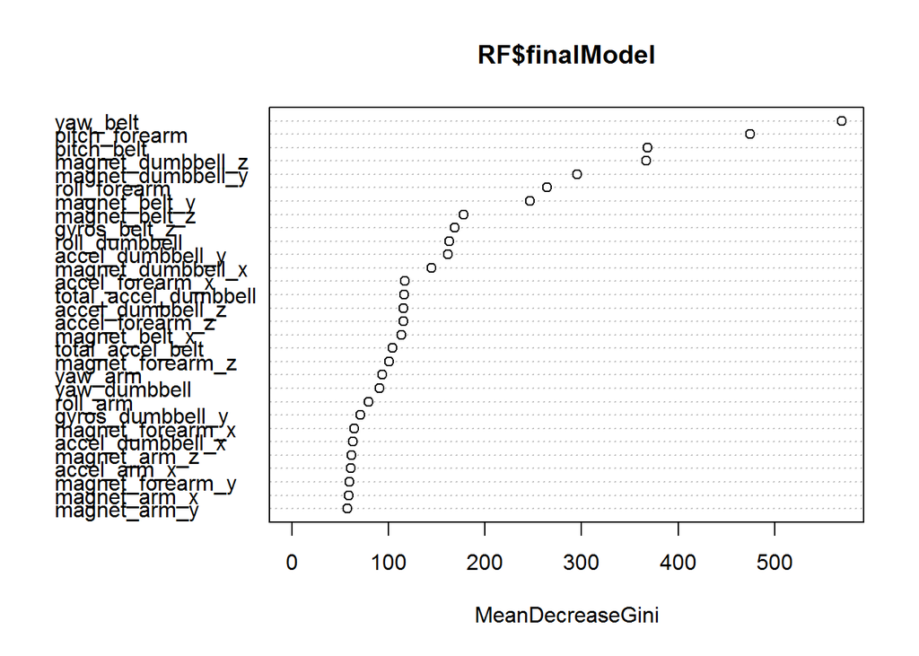

```r
varImpPlot(RF$finalModel)
```

```r
test <- read.csv("pml-testing.csv", na.strings=c("", "NA"))
test <- test[,colSums(is.na(test))<5]  ##get rid of columns with many NA
test <- test[,-(1:7)]  ##get rid of variables name, timestamp etc.
test[,1:52] <- sapply(test[,1:52], as.numeric)   ##make all variables numeric
```

Now the model is applied on the test set and the predictions based on the model are shown.

```r
Prediction_test = predict(RF, newdata=test)
Prediction_test
```

```
##  [1] B A B A A E D B A A B C B A E E A B B B
## Levels: A B C D E
```